# K Means

Kyle Safran

June 3, 2017

## K Means

K Means is an unsupervised clustering technique that helps uncover structure in your data. It is computationally cheap relative to hierarchical clustering (you don’t need to compute a huge distance matrix), but you do need to provide k (the number of clusters) up front. We can use the old faithful dataset to test out this algorithm.

## Old Faithful

The Old Faithful dataset shows the relationship between the length of time between eruptions and the length of an eruption. As you can see from the plot below, it looks like there are two categories of eruptions. We can uncover these clusters using the K Means algorithm.

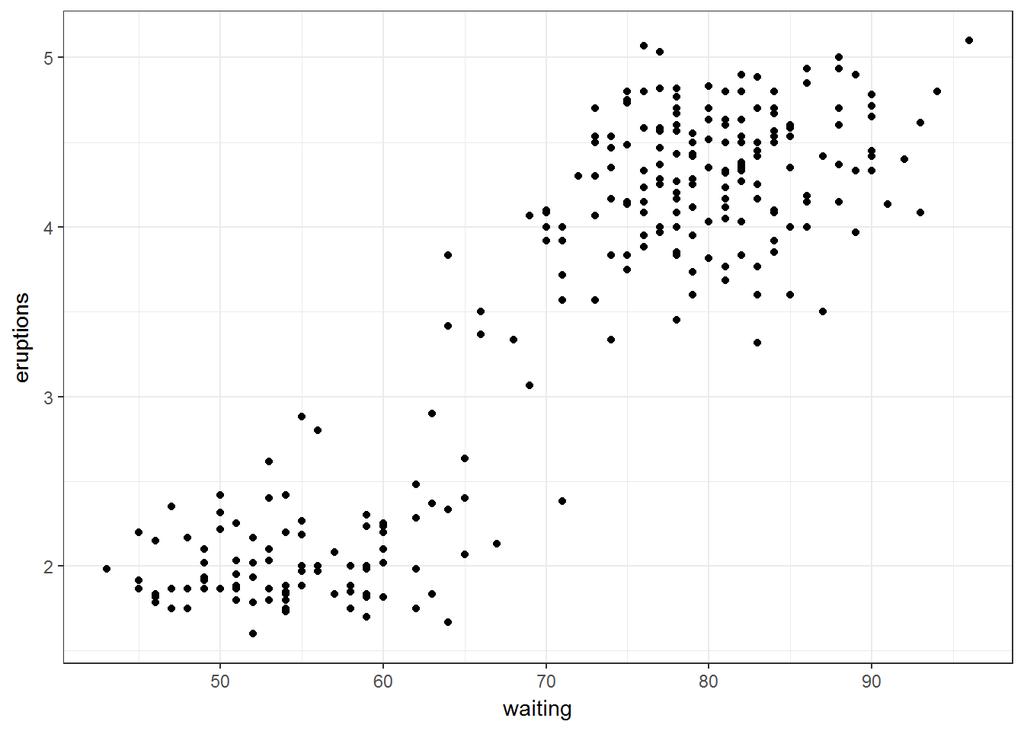

```r
data(faithful)
ggplot() +
  geom_point(aes(x = waiting, y = eruptions),
             data = faithful) +
  theme_bw()
```

## Algorithm

Since this algorithm relies on distance measure, we want to scale the data. Then we initialize the algorithm by selecting k = 2 random points, and arbitrarily assign them a classification. An easy way to do this is to just randomly pick two points in our dataset.

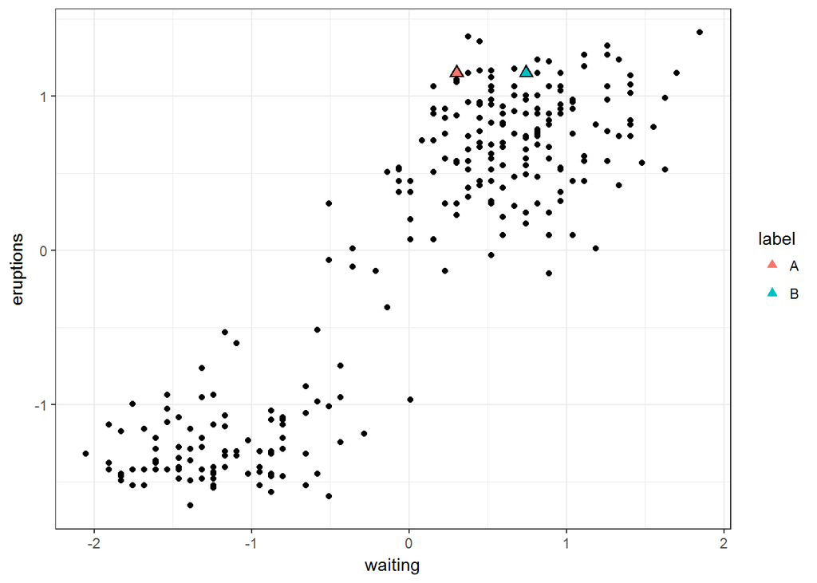

Next we assign each of the points in the dataset to the class of the nearest centroid.

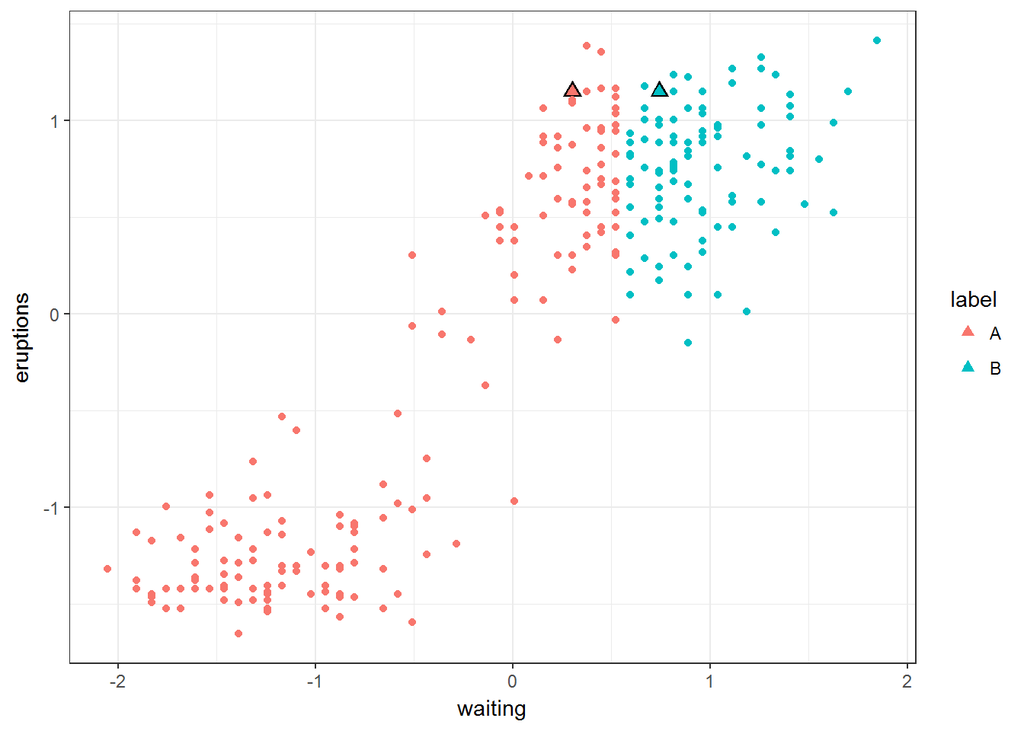

```r
euc_distance <- function(x1, x2) sqrt(sum((x1 - x2) ^ 2))
closest_centroid <- function(x, centroids){
  apply(centroids[, 1:2], 1, euc_distance, x) %>%
    which.min()
}
assign_label <- function(data, centroids){
  ind <- apply(data[, 1:2], 1, closest_centroid, centroids)
  centroids$label[ind]
}
faithful$label <- assign_label(faithful, centroids)
ggplot() +
  geom_point(aes(x = waiting, y = eruptions),
             data = centroids, size = 3, shape = 17) +
  geom_point(aes(x = waiting, y = eruptions, col = label),
             data = centroids, size = 2, shape = 17) +
  geom_point(aes(x = waiting, y = eruptions, col = label),
             data = faithful) +
  theme_bw()
```

Next we need to update the centroids to the center of each group.

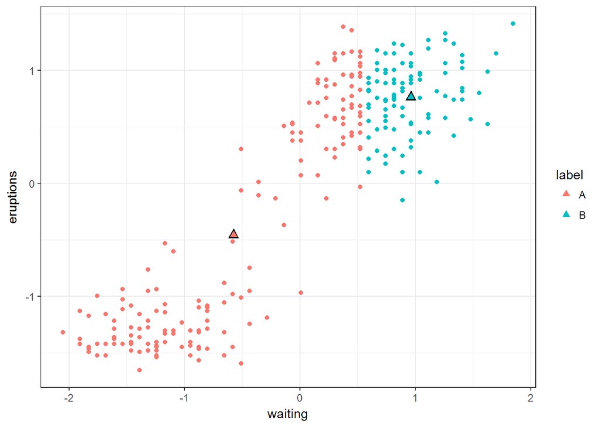

```r
update_centroids <- function(data, centroids){
  new.centers <- data %>%
    group_by(label) %>%
    summarize(eruptions.center = mean(eruptions),
              waiting.center = mean(waiting))

  centroids[1:2, 1:2] <- new.centers[1:2, 2:3]
  centroids
}
centroids <- update_centroids(faithful, centroids)


ggplot() +
  geom_point(aes(x = waiting, y = eruptions),
             data = centroids, size = 3, shape = 17) +
  geom_point(aes(x = waiting, y = eruptions, col = label),
             data = centroids, size = 2, shape = 17) +
  geom_point(aes(x = waiting, y = eruptions, col = label),
             data = faithful) +
  theme_bw()
```

Now we just repeat the assignment and centroid update steps until we get convergence. The following animation shows the entire process.

[video not shown]